# The impact of external factors on a student’s performance

An analysis of UCI’s *Student Performance* dataset

510415022, 500456970, 510512974

University of Sydney | MATH1005 | Thursday, Lab Class 10 @ 11am | Carslaw Building 353

# 1 Executive Summary

The aim of the report is to investigate the performance of students attending two public schools in Portugal. Specific areas of interest include the effect of weekday alcohol consumption on student performance, as well as the performance of students studying Portuguese over two semesters.

The analysis showed that there was no discernible relationship between grades and alcohol consumption, a common finding in previous studies of these two variables. However, there was a perceivable change in the distribution of grades, becoming increasingly negative with increased alcohol intake.

Additionally, students studying Portuguese across both schools experienced on average a decrease in performance with a larger proportion of GP students experiencing this decrease. This aligned with studies identifying the low graduation rate and generally poorer education climate in Portugal.

# 2 Full Report

## 2.1 Initial Data Analysis (IDA)

### 2.1.1 Source

The data is originally sourced from the study *Using data mining to predict secondary school student performance* (Cortez and Silva 2008). This study primarily focuses on predicting a student’s final grade of the year given their past examination results, and then examining which variables affect student success in school to a higher degree.

In order to conduct the study, researchers collected first-hand data about 788 students studying Mathematics and Portuguese in two public schools using school reports and a questionnaire. The questionnaire was designed as to limit variability in the responses, and hence most questions have predetermined responses, with questions focusing on “demographic (e.g. mother’s education, family income), social/emotional (e.g. alcohol consumption)…and school related (e.g. number of past class failures) variables” (Cortez and Silva 2008). The data has therefore been collected by a reputable source and is largely valid.

The largest issue with the method used by these researchers to collect their data is using an arbitrary 1 - 5 scale for a large proportion of predetermined responses. For example, `famrel`, `freetime`, `goout`, `Dalc` (workday alcohol consumption), `Walc` (weekend alcohol consumption), and `health` are all variables which require the respondents to judge their own social and emotional habits from 1 to 5, with absolutely no quantitative scale for what each number might represent. Compare this to the `traveltime` and `studytime` variables which have been given definite numerical ‘bins’ per response e.g. for `studytime` we have a scale of 1 to 4 with the following guidelines:

- 1: <2 hours
- 2: 2 to 5 hours
- 3: 5 to 10 hours
- or 4: >10 hours

Potential stakeholders for a study on the factors affecting a student’s performance are educators all around the world including teachers and principals but also policy-makers and legislators.

### 2.1.2 Variables

There are initially two datasets provided: one for Mathematics students (`d1`) and one for Portuguese students (`d2`).

```r
# students studying Mathematics
d1 = read.csv("student/student-mat.csv", sep = ";", header = TRUE)

# students studying Portuguese
d2 = read.csv("student/student-por.csv", sep = ";", header = TRUE)
```

```r
# observe dimensions of each dataset
dim(d1)
```

```
## [1] 395  33
```

```r
dim(d2)
```

```
## [1] 649  33
```

```r
# we view the variable names that are contained in the dataset using the `names` function
variables = names(d1)
variables
```

```
##  [1] "school"     "sex"        "age"        "address"    "famsize"
##  [6] "Pstatus"    "Medu"       "Fedu"       "Mjob"       "Fjob"
## [11] "reason"     "guardian"   "traveltime" "studytime"  "failures"
## [16] "schoolsup"  "famsup"     "paid"       "activities" "nursery"
## [21] "higher"     "internet"   "romantic"   "famrel"     "freetime"
## [26] "goout"      "Dalc"       "Walc"       "health"     "absences"
## [31] "G1"         "G2"         "G3"
```

Both datasets contain 33 columns, each representing a different variable of a student’s life. Each row represents one student’s information, hence the Mathematics dataset has 395 students and the Portuguese dataset has 649 students.

#### 2.1.2.1 Classification of variables

Checking whether `R` has correctly identified the datatype of each variable;

```r
str(d1)
```

```
## 'data.frame':    395 obs. of  33 variables:
##  $ school    : chr  "GP" "GP" "GP" "GP" ...
##  $ sex       : chr  "F" "F" "F" "F" ...
##  $ age       : int  18 17 15 15 16 16 16 17 15 15 ...
##  $ address   : chr  "U" "U" "U" "U" ...
##  $ famsize   : chr  "GT3" "GT3" "LE3" "GT3" ...
##  $ Pstatus   : chr  "A" "T" "T" "T" ...
##  $ Medu      : int  4 1 1 4 3 4 2 4 3 3 ...
##  $ Fedu      : int  4 1 1 2 3 3 2 4 2 4 ...
##  $ Mjob      : chr  "at_home" "at_home" "at_home" "health" ...
##  $ Fjob      : chr  "teacher" "other" "other" "services" ...
##  $ reason    : chr  "course" "course" "other" "home" ...
##  $ guardian  : chr  "mother" "father" "mother" "mother" ...
##  $ traveltime: int  2 1 1 1 1 1 1 2 1 1 ...
##  $ studytime : int  2 2 2 3 2 2 2 2 2 2 ...
```

[output cut: 19 more lines]

It appears as though there are many variables which *should* be classified as a `logical` but currently are represented `chr` datatype (`schoolsup` to `romantic`). The `to_logical` function from the `batman` package can automatically convert these to their correct datatype:

```r
# load in the batman library
library(batman)

# assigning each variable to the restructured version [d1]
d1$schoolsup = to_logical(d1$schoolsup)
d1$famsup = to_logical(d1$famsup)
d1$paid = to_logical(d1$paid)
d1$activities = to_logical(d1$activities)
d1$nursery = to_logical(d1$nursery)
d1$higher = to_logical(d1$higher)
d1$internet = to_logical(d1$internet)
d1$romantic = to_logical(d1$romantic)

# assigning each variable to the restructured version [d2]
d2$schoolsup = to_logical(d2$schoolsup)
d2$famsup = to_logical(d2$famsup)
d2$paid = to_logical(d2$paid)
d2$activities = to_logical(d2$activities)
d2$nursery = to_logical(d2$nursery)
d2$higher = to_logical(d2$higher)
d2$internet = to_logical(d2$internet)
d2$romantic = to_logical(d2$romantic)
```

```r
# now the structure of both datasets is accurately represented in R.

str(d1)
```

```
## 'data.frame':    395 obs. of  33 variables:
##  $ school    : chr  "GP" "GP" "GP" "GP" ...
##  $ sex       : chr  "F" "F" "F" "F" ...
##  $ age       : int  18 17 15 15 16 16 16 17 15 15 ...
##  $ address   : chr  "U" "U" "U" "U" ...
##  $ famsize   : chr  "GT3" "GT3" "LE3" "GT3" ...
##  $ Pstatus   : chr  "A" "T" "T" "T" ...
##  $ Medu      : int  4 1 1 4 3 4 2 4 3 3 ...
##  $ Fedu      : int  4 1 1 2 3 3 2 4 2 4 ...
##  $ Mjob      : chr  "at_home" "at_home" "at_home" "health" ...
##  $ Fjob      : chr  "teacher" "other" "other" "services" ...
##  $ reason    : chr  "course" "course" "other" "home" ...
##  $ guardian  : chr  "mother" "father" "mother" "mother" ...
##  $ traveltime: int  2 1 1 1 1 1 1 2 1 1 ...
##  $ studytime : int  2 2 2 3 2 2 2 2 2 2 ...
```

[output cut: 19 more lines]

```r
# now the structure of both datasets is accurately represented in R.
str(d2)
```

```
## 'data.frame':    649 obs. of  33 variables:
##  $ school    : chr  "GP" "GP" "GP" "GP" ...
##  $ sex       : chr  "F" "F" "F" "F" ...
##  $ age       : int  18 17 15 15 16 16 16 17 15 15 ...
##  $ address   : chr  "U" "U" "U" "U" ...
##  $ famsize   : chr  "GT3" "GT3" "LE3" "GT3" ...
##  $ Pstatus   : chr  "A" "T" "T" "T" ...
##  $ Medu      : int  4 1 1 4 3 4 2 4 3 3 ...
##  $ Fedu      : int  4 1 1 2 3 3 2 4 2 4 ...
##  $ Mjob      : chr  "at_home" "at_home" "at_home" "health" ...
##  $ Fjob      : chr  "teacher" "other" "other" "services" ...
##  $ reason    : chr  "course" "course" "other" "home" ...
##  $ guardian  : chr  "mother" "father" "mother" "mother" ...
##  $ traveltime: int  2 1 1 1 1 1 1 2 1 1 ...
##  $ studytime : int  2 2 2 3 2 2 2 2 2 2 ...
```

[output cut: 19 more lines]

In IQ1 we are interested in analysing data from students who have done both Mathematics and Portuguese, and so we must merge these two datasets to find the unique entries.

```r
data = merge(d1, d2, by = c("school", "sex", "age", "address", "famsize", "Pstatus", "Medu", "Fedu", "Mjob", "Fjob", "reason", "nursery", "internet", "Dalc"))

# print dimensions of merged dataset
dim(data)
```

```
## [1] 377  52
```

#### 2.1.2.2 Description of key variables

The key numeric variables here are `G1`, `G2` and `G3`, which represent the student’s mark in the three schooling terms of the Portuguese calendar from 0 to 20. `dalc` represents the weekday alcohol consumption of a given student given as a double on an increasing continuous numeric scale from 1 to 5.

## 2.2 Research Question 1: What is the impact of alcohol consumption on student performance?

Here we compare the final average grades (`G3`) of students who studied both Mathematics and Portuguese to their weekday alcohol consumption (`Dalc`).

### 2.2.1 Comparing grades with weekday alcohol consumption

We averaged the Mathematics and Portuguese grades, `d3$G3.x`, `d3$G3.y` and separated the data based on the `Dalc` nominal scale, storing them into five variables. We produce 5 boxplots with the mean notated on each.

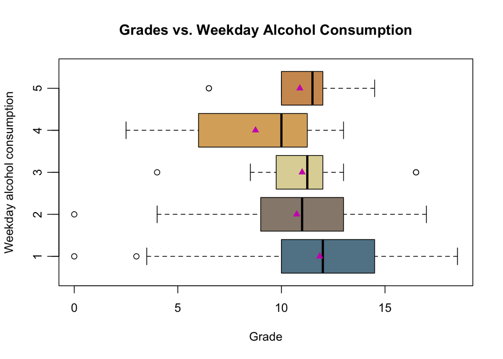

```r
# Weekday Alcohol Consumption vs. Grades

# average of Mathematics (.x) and Portuguese (.y) grades of students who chose a 1, 2, 3, 4 or 5 for weekday alcohol consumption, respectively
verylow = ((data$G3.x + data$G3.y)/2)[data$Dalc == 1]
low = ((data$G3.x + data$G3.y)/2)[data$Dalc == 2]
medium = ((data$G3.x + data$G3.y)/2)[data$Dalc == 3]
high = ((data$G3.x + data$G3.y)/2)[data$Dalc == 4]
veryhigh = ((data$G3.x + data$G3.y)/2)[data$Dalc == 5]

# producing 5 boxplots with relevant title and axis labels
boxplot(verylow, low, medium, high, veryhigh,
        horizontal = T,
        xlab = "Grade",
        ylab = "Weekday alcohol consumption",
        main = "Grades vs. Weekday Alcohol Consumption",
        col = c("#628395", "#96897b", "#dfd5a5", "#dbad6a", "#cf995f"),
        xmax = 20,
        notch = FALSE)

y = c(1, 2, 3, 4, 5) # storing variable to set ticks for y axis
y_label = c("1", "2", "3", "4", "5") # storing variable to label ticks y axis

axis(side = 2,
     at = y,
     labels = y_label,
     tck = -.05) # setting and labelling ticks on y axis

# plotting means onto each boxplot
points(mean(verylow), 1, col = 6, pch = 17)
points(mean(low), 2, col = 6, pch = 17)
points(mean(medium), 3, col = 6, pch = 17)
points(mean(high), 4, col = 6, pch = 17)
points(mean(veryhigh), 5, col = 6, pch = 17)
```

```r
# Finding the number of students in each category:
length(verylow)
```

```
## [1] 265
```

```r
length(low)
```

```
## [1] 71
```

```r
length(medium)
```

```
## [1] 24
```

```r
length(high)
```

```
## [1] 8
```

```r
length(veryhigh)
```

```
## [1] 9
```

The median grade remains relatively constant between the categories of alcohol consumption. With higher alcohol consumption the grades become more negatively skewed with a lower mean than median. This indicates that with increased weekday alcohol intake, the results became more variable and there were more students who performed worse than what would be expected, reducing the overall mean.

Furthermore, the spread of data decreased with increased alcohol consumption with the maximum score decreasing and minimum scores increasing. This is with the exception of the “high” and “very high” categories, likely due to the low number of students in these categories (“high” and “very high” had 8 and 9 students compared to 265, 71 and 24 students in the “very low”, “low” and “medium” categories respectively). This likely skewed the sample.

### 2.2.2 Limitations

Apart from the imbalance of students in each category, another limitation of this dataset is that the study does not mention what question was asked to participants when choosing from this scale. It is unclear whether the question was subjective (i.e. how much do you think you drink each week?) or more objective (i.e. do you drink 5 drinks per week, 10 drinks etc.? with a scale based on the number of drinks per week). If it was subjective, many students may have exaggerated their weekday alcohol consumption, resulting in a skewed sample. This may explain why those with very high alcohol consumption achieved better-than-expected grades.

### 2.2.3 Concluding remarks and additional research

Overall, the relationship between grades and weekday alcohol consumption in this dataset was nonexistent. Whilst the potential physical and psychological effects of alcohol consumption are well-documented, with Portugal having the “highest alcohol consumption and linked alcohol problems” in the European Union (Goncalves and Sousa Carvalho, n.d.), the direct relationship between alcohol intake and grades has not been established (Balsa, Giuliano, and French 2011). Some state that “teen drinking does not have an independent effect on educational attainment” (Evans and Dee 2003) whilst others are of the opinion that there may be too many confounders in the heterogeneity of participants (Balsa, Giuliano, and French 2011). However, the limitations of these studies is that they were all published over 10 years ago and so may not accurately represent teenagers in today’s society and, were focused on other variables such as gender and legislation in relation to drinking thus, altering the sample to also accommodate for these.

## 2.3 Research Question 2: Comparing Portuguese marks across semesters (`G1` vs `G2`) and across schools (`GP` vs `MS`)

We investigate the growth in Portuguese performance across two schools in order to identify a correlation between school and Portuguese performance. The results are derived from two different public schools where there may exist a difference in curriculum, quality of teaching, or general well-being. While Portugal has ‘improved dramatically’ in its social and economic sectors, it has ‘not yet reached the standards of living’ (Domingos 2009) of other EU counterparts. In 2002, only about 45% students graduated from secondary school compared to a mean of more than 80% for OECD countries (Domingos 2009).

```r
# we separate the variables `G1.y`, `G2.y` by school

G1.y.GP = d2$G1[d2$school == 'GP'] # GP Portuguese student marks in G1
G1.y.MS = d2$G1[d2$school == 'MS'] # MS Portuguese student marks in G1

G2.y.GP = d2$G2[d2$school == 'GP'] # GP Portuguese student marks in G2
G2.y.MS = d2$G2[d2$school == 'MS'] # MS Portuguese student marks in G2
```